# Lesson2-7-20-2023

Aaron Mamula

6/22/2023

# 1. Resources

- [Software Carpentry Module on R and R Studio](https://swcarpentry.github.io/r-novice-gapminder/01-rstudio-intro.html)
- [Some reading on packages and libraries](https://hbctraining.github.io/Intro-to-R-flipped/lessons/04_introR_packages.html)

# 2. Objectives:

1. Create an R Studio Project

   A. populate the project with some data

   B. populate the project with some R code
2. Use R Studio to replicate the Soquel Creek Flow Analysis

# 3. Exercise 1: Create a Project

1. In RStudio: File –> New Project –> New Directory –> New Project
2. In your file explorer navigate to the directory for your new RStudio Project and add a subdirectory called “Data”
3. Copy the [SoquelCreek.csv](https://drive.google.com/file/d/1QxBDwmIinIH88W-LFfr3lXRYrTmLXf4r/view?usp=drive_link) file into the `Data` subdirectory
4. Open your RStudio project and create a code file: File –> New File –> R Script
5. Name the new code file “Analysis.R”
6. Copy the following syntax into your “Analysis.R” document

```r
stream_data <- read.csv("Data/SoquelCreek.csv")
stream_data$Date <- as.Date(stream_data$Date,format="%m/%d/%Y")
```

# 4. Exercise 2: Use R Studio to Replicate an Analysis

1. Go to the [HPP-2023-RepRes](https://drive.google.com/drive/folders/164ikcxKNUtzSiatY1jK0fA-nab6QpGmb?usp=drive_link) directory in Google Drive
2. Download the entire directory and save it to a local directory (or just let it linger in your “Downloads” directory)
3. Open the directory, navigate to `HPP-2023-RepRes.Rproj`, open the project
4. Inside the R Studio project, navigate to the `Files` tab of the `Files, Plots, Packages, Help, Viewer, Presentation` pane
5. click on the `code.R` file to open it
6. Highlight the code and run it (use the `Run` icon at the top right of the `Source` pane or your keyboard shortcuts)

The R script in `code.R` does a few very simple things:

1. imports the Soquel Creek Flow data into the workspace
2. changes the Date variable to a Date class object
3. creates a plot of monthly flow values for Soquel Creek

The purpose of this exercise is to illustrate how R Studio Projects promote reproducability. By packaging everything (code + data) into an R Studio Project, I enable others to reproduce my analysis exactly as intended without lots of extra steps and roadblocks.

# 5. Lesson Background and Narrative

This lesson deals with the *WHY* of learning R. Specifically, this lesson focuses on why many scientists that I know are enthusiastic about R:

**REPRODUCABLE RESEARCH**

[figure not shown]

Scientific results need to be reproducible

- we need to know that results aren’t due to basic mistakes (typos, etc.)
  - in order to know this, others need to understand the details of what you did.
- we often would like to know whether results can be applied broadly or if they only apply in some very limited circumstances

In both of these cases we need to be able to provide other researchers with our analysis and dependencies so that they can try to replicate our results.

## 5.1. How do R and R Studio help with this?

R is a programming language. Using R allows you to record the steps of your analysis in a way that preserves everything you’ve done.

R Studio is a software tool that organizes your R code and dependencies (data files for example) so that it can be easily shared with others that might seek to replicate your analysis.

There are many good reasons to organize your work in projects. You can read a more thorough discussion the advantages of organizing work as project [in this Software Carpentry Module](https://swcarpentry.github.io/r-novice-gapminder/02-project-intro/index.html). I’m not qualified to talk about all the magnificent ways that RStudio Projects will change your lives, I’m only really qualified to discuss why I find them advantageous: Organizing work in projects makes it self-contained which makes it easily reproducible and shareable.

# 6. Workflow Example

In Economics and Social Science we are often tasked with using observational data (as opposed to controlled experimentation) to answer questions. Suppose we are given a data set including property values (home prices) for individual homes and their addresses. We are asked to evaluate the impact of proximity to a landfill on property values. Suppose also that we want to do the analysis in Excel (or some other spreadsheet type application).

As a first pass we decide to:

- Step 1: calculate the distance of each home to the landfill - At a minimum this will involve creating a new column in the spreadsheet and embedding a formula in this column.
- Step 2: create a categorical variable indicating whether each property is
  - less than 1 mile from the landfill
  - between 1 mile and 2 miles from the landfill
  - more than 2 miles from the landfill

This will again necessitate creating a new column and embedding a formula to generate the categorical distance variable.

- Step 3: take the average of home prices in each of the 3 distance bands - to do this one would most likely create another sheet and, in three separate cells in the new sheet, insert a formula equal to the average of certain highlighted cells from the first sheet.

If the average price is lower for the homes in the `less than 1 mile` distance band compared to the other two distance bands we might conclude that being close to a landfill does have a negative effect on home prices.

Now suppose we want to refine this analysis.

## 6.2. Problems

1. This type of analysis will be very difficult and potentially impossible for a researcher who is not you to reproduce. This is because all of the work is contained in formulas that are embedded in cells that all reference other collections of cells. It would be incredibly difficult for another researcher to untangle what you did because there is no clear record of it.
2. This type of analysis will also be very difficult for you to reproduce. And if results can’t be reproduced, they can’t be taken seriously. Consider the following hypothetical:

Suppose you decide that the 3 distance bands (less than 1 mile, 1 mile to 2 miles, and more than 2 miles from the landfill) are too coarse and you want to redo your analysis using different distance bands:

## 6.3. Solution

1. If our data manipulations are memorialized in code (rather than existing as embedded formulas in a spreadsheet) and saved in a text document then we will always have a reference for exactly what we did.
   - this is the `R` part: use a code-based solution to preserve analytical operations
2. If our data are kept separate from our code and treated as ‘Read Only’ we won’t have to worry about altering source data with data manipulations.
   - this is the R Studio part: use R Studio to bundle code and data in order to easily share your work.

In general:

A. When the number of data manipulations is small, the researcher can probably keep track of each one if they are meticulous about documenting each step. When the number of data manipulations grows so does the probability that one of these operations won’t be properly documented and the researcher will end up with a set of tables with numbers in them, the origin of which is totally unknown.

[output not shown]

B. If there is only 1 person working on this project maybe it’s possible to document every single data manipulation properly. But what if two people are working on the project together from different locations. Imagine that one of those people makes a table that summarizes the weekly maximum lake level value over time. Then the other person thinks it’s strange that the lake level values are in feet instead of meters and decides to convert them. This changes all the values in the tables that are linked to the data. And what if one of those tables has already been copied over to a Microsoft Word document for a report? Now we have a table in the Excel file that should match the table that copied into the report but does not.

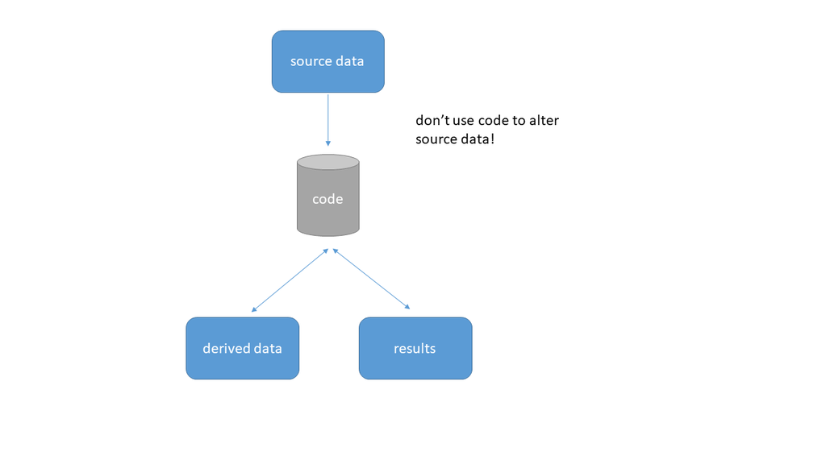